# **LOAN DEFAULT PREDICTION: A BINARY CLASSIFICATION APPROACH**

```python
import pandas as pd
import numpy as np
import seaborn as sns
import matplotlib.pyplot as plt
```

```python
url = "https://drive.google.com/uc?export=download&id=1EYNkHsz4iWU3O6ctD2OZP3DD52UGi5aT"
data = pd.read_csv(url)
pd.set_option('display.max_columns', None)
pd.set_option('display.width', 300)
print(data.info())
data.head(5)
```

```
<class 'pandas.core.frame.DataFrame'>
RangeIndex: 148670 entries, 0 to 148669
Data columns (total 34 columns):
 #   Column                     Non-Null Count   Dtype
---  ------                     --------------   -----
 0   ID                         148670 non-null  int64
 1   year                       148670 non-null  int64
 2   loan_limit                 145326 non-null  object
 3   Gender                     148670 non-null  object
 4   approv_in_adv              147762 non-null  object
 5   loan_type                  148670 non-null  object
 6   loan_purpose               148536 non-null  object
 7   Credit_Worthiness          148670 non-null  object
 8   open_credit                148670 non-null  object
 9   business_or_commercial     148670 non-null  object
```

[output cut: 27 more lines]

|  | ID | year | loan_limit | Gender | approv_in_adv | loan_type | loan_purpose | Credit_Worthiness | open_credit | business_or_commercial | loan_amount | rate_of_interest | Interest_rate_spread | Upfront_charges | term | Neg_ammortization | interest_only | lump_sum_payment | property_value | construction_type | occupancy_type | Secured_by | total_units | income | credit_type | Credit_Score | co-applicant_credit_type | age | submission_of_application | … |
| --- | --- | --- | --- | --- | --- | --- | --- | --- | --- | --- | --- | --- | --- | --- | --- | --- | --- | --- | --- | --- | --- | --- | --- | --- | --- | --- | --- | --- | --- | --- |
| 0 | 24890 | 2019 | cf | Sex Not Available | nopre | type1 | p1 | l1 | nopc | nob/c | 116500 | NaN | NaN | NaN | 360.0 | not_neg | not_int | not_lpsm | 118000.0 | sb | pr | home | 1U | 1740.0 | EXP | 758 | CIB | 25-34 | to_inst | … |
| 1 | 24891 | 2019 | cf | Male | nopre | type2 | p1 | l1 | nopc | b/c | 206500 | NaN | NaN | NaN | 360.0 | not_neg | not_int | lpsm | NaN | sb | pr | home | 1U | 4980.0 | EQUI | 552 | EXP | 55-64 | to_inst | … |
| 2 | 24892 | 2019 | cf | Male | pre | type1 | p1 | l1 | nopc | nob/c | 406500 | 4.56 | 0.2000 | 595.0 | 360.0 | neg_amm | not_int | not_lpsm | 508000.0 | sb | pr | home | 1U | 9480.0 | EXP | 834 | CIB | 35-44 | to_inst | … |
| 3 | 24893 | 2019 | cf | Male | nopre | type1 | p4 | l1 | nopc | nob/c | 456500 | 4.25 | 0.6810 | NaN | 360.0 | not_neg | not_int | not_lpsm | 658000.0 | sb | pr | home | 1U | 11880.0 | EXP | 587 | CIB | 45-54 | not_inst | … |
| 4 | 24894 | 2019 | cf | Joint | pre | type1 | p1 | l1 | nopc | nob/c | 696500 | 4.00 | 0.3042 | 0.0 | 360.0 | not_neg | not_int | not_lpsm | 758000.0 | sb | pr | home | 1U | 10440.0 | CRIF | 602 | EXP | 25-34 | not_inst | … |

```python
# Super basic cleaning:
# '''''''''''''''''''''

df = data.drop_duplicates()

df.columns = (
    df.columns
      .str.strip()
      .str.replace(' ', '_')
      .str.replace('-', '_')
      .str.replace('/', '_')
)

noise_values = ['NA','na','N/A','?', 'null', 'None', 'none', '', 'sex not available']
df = df.replace(noise_values, np.nan)

for col in df.columns:
    df[col] = pd.to_numeric(df[col], errors='ignore')

cat_cols = df.select_dtypes(include='object').columns
df[cat_cols] = df[cat_cols].apply(lambda x: x.str.lower().str.strip())

df['Status'] = df['Status'].astype(int)

print(df.shape)
print(df.info())
df.head(1)
```

```
(148670, 34)
<class 'pandas.core.frame.DataFrame'>
RangeIndex: 148670 entries, 0 to 148669
Data columns (total 34 columns):
 #   Column                     Non-Null Count   Dtype
---  ------                     --------------   -----
 0   ID                         148670 non-null  int64
 1   year                       148670 non-null  int64
 2   loan_limit                 145326 non-null  object
 3   Gender                     148670 non-null  object
 4   approv_in_adv              147762 non-null  object
 5   loan_type                  148670 non-null  object
 6   loan_purpose               148536 non-null  object
 7   Credit_Worthiness          148670 non-null  object
 8   open_credit                148670 non-null  object
```

[output cut: 28 more lines]

|  | ID | year | loan_limit | Gender | approv_in_adv | loan_type | loan_purpose | Credit_Worthiness | open_credit | business_or_commercial | loan_amount | rate_of_interest | Interest_rate_spread | Upfront_charges | term | Neg_ammortization | interest_only | lump_sum_payment | property_value | construction_type | occupancy_type | Secured_by | total_units | income | credit_type | Credit_Score | co_applicant_credit_type | age | submission_of_application | … |
| --- | --- | --- | --- | --- | --- | --- | --- | --- | --- | --- | --- | --- | --- | --- | --- | --- | --- | --- | --- | --- | --- | --- | --- | --- | --- | --- | --- | --- | --- | --- |
| 0 | 24890 | 2019 | cf | sex not available | nopre | type1 | p1 | l1 | nopc | nob/c | 116500 | NaN | NaN | NaN | 360.0 | not_neg | not_int | not_lpsm | 118000.0 | sb | pr | home | 1u | 1740.0 | exp | 758 | cib | 25-34 | to_inst | … |

```python
# Missing values with proportion
total_rows = len(df)
missing_info = []

for col in df.columns:
    na = df[col].isnull().sum()
    if na > 0:
        proportion = na / total_rows
        missing_info.append((col, na, proportion))

if missing_info:
    missing_info = sorted(missing_info, key=lambda x: x[2])
    for col, na, proportion in missing_info:
        print(f"Column {col} has {na:,} missing values ({proportion:.2%} of total).")
else:
    print("There is no missing value in this dataset.")
```

```
Column term has 41 missing values (0.03% of total).
Column Neg_ammortization has 121 missing values (0.08% of total).
Column loan_purpose has 134 missing values (0.09% of total).
Column age has 200 missing values (0.13% of total).
Column submission_of_application has 200 missing values (0.13% of total).
Column approv_in_adv has 908 missing values (0.61% of total).
Column loan_limit has 3,344 missing values (2.25% of total).
Column income has 9,150 missing values (6.15% of total).
Column property_value has 15,098 missing values (10.16% of total).
Column LTV has 15,098 missing values (10.16% of total).
Column dtir1 has 24,121 missing values (16.22% of total).
Column rate_of_interest has 36,439 missing values (24.51% of total).
Column Interest_rate_spread has 36,639 missing values (24.64% of total).
Column Upfront_charges has 39,642 missing values (26.66% of total).
```

```
         Count  Percentage
Status
0       112031   75.355485
1        36639   24.644515
```

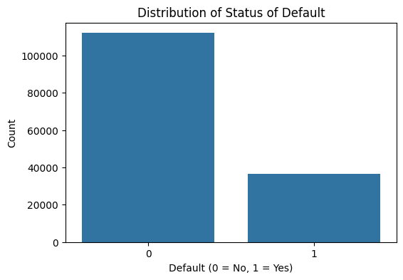

```python
# Check class imbalance
class_counts = df['Status'].value_counts()
class_percent = df['Status'].value_counts(normalize=True) * 100

balance_df = pd.DataFrame({
    'Count': class_counts,
    'Percentage': class_percent
})

print(balance_df)

# Graphically
plt.figure(figsize=(6,4))
sns.countplot(x='Status', data=df)
plt.title('Distribution of Status of Default')
plt.xlabel('Default (0 = No, 1 = Yes)')
plt.ylabel('Count')
plt.show()
```

```python
# Optional: make numbers easier to read
pd.set_option('display.float_format', '{:.2f}'.format)

# Separate numeric & categorical again
num_cols = df.select_dtypes(include=['float64','int64']).columns.tolist()
cat_cols = df.select_dtypes(include='object').columns.tolist()

print("\nNumeric columns:", num_cols)
print("\nCategorical columns:", cat_cols)

# ---- BASIC NUMERIC SUMMARY ----
print("\n==== NUMERIC SUMMARY STATISTICS ====")
df[num_cols].describe()
```

```
Numeric columns: ['ID', 'year', 'loan_amount', 'rate_of_interest', 'Interest_rate_spread', 'Upfront_charges', 'term', 'property_value', 'income', 'Credit_Score', 'LTV', 'Status', 'dtir1']

Categorical columns: ['loan_limit', 'Gender', 'approv_in_adv', 'loan_type', 'loan_purpose', 'Credit_Worthiness', 'open_credit', 'business_or_commercial', 'Neg_ammortization', 'interest_only', 'lump_sum_payment', 'construction_type', 'occupancy_type', 'Secured_by', 'total_units', 'credit_type', 'co_a…

==== NUMERIC SUMMARY STATISTICS ====
```

|  | ID | year | loan_amount | rate_of_interest | Interest_rate_spread | Upfront_charges | term | property_value | income | Credit_Score | LTV | Status | dtir1 |
| --- | --- | --- | --- | --- | --- | --- | --- | --- | --- | --- | --- | --- | --- |
| count | 148670.00 | 148670.00 | 148670.00 | 112231.00 | 112031.00 | 109028.00 | 148629.00 | 133572.00 | 139520.00 | 148670.00 | 133572.00 | 148670.00 | 124549.00 |
| mean | 99224.50 | 2019.00 | 331117.74 | 4.05 | 0.44 | 3225.00 | 335.14 | 497893.47 | 6957.34 | 699.79 | 72.75 | 0.25 | 37.73 |
| std | 42917.48 | 0.00 | 183909.31 | 0.56 | 0.51 | 3251.12 | 58.41 | 359935.32 | 6496.59 | 115.88 | 39.97 | 0.43 | 10.55 |
| min | 24890.00 | 2019.00 | 16500.00 | 0.00 | -3.64 | 0.00 | 96.00 | 8000.00 | 0.00 | 500.00 | 0.97 | 0.00 | 5.00 |
| 25% | 62057.25 | 2019.00 | 196500.00 | 3.62 | 0.08 | 581.49 | 360.00 | 268000.00 | 3720.00 | 599.00 | 60.47 | 0.00 | 31.00 |
| 50% | 99224.50 | 2019.00 | 296500.00 | 3.99 | 0.39 | 2596.45 | 360.00 | 418000.00 | 5760.00 | 699.00 | 75.14 | 0.00 | 39.00 |
| 75% | 136391.75 | 2019.00 | 436500.00 | 4.38 | 0.78 | 4812.50 | 360.00 | 628000.00 | 8520.00 | 800.00 | 86.18 | 0.00 | 45.00 |
| max | 173559.00 | 2019.00 | 3576500.00 | 8.00 | 3.36 | 60000.00 | 360.00 | 16508000.00 | 578580.00 | 900.00 | 7831.25 | 1.00 | 61.00 |

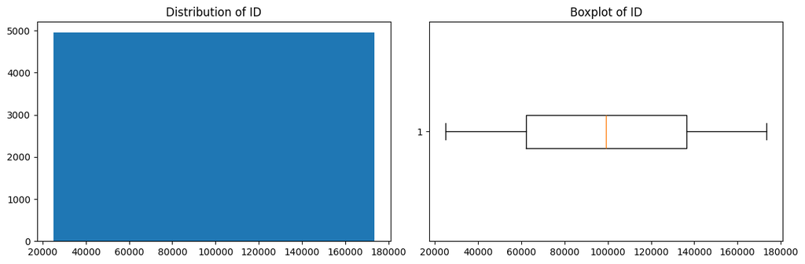

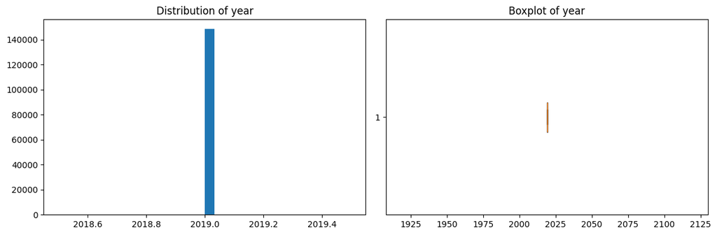

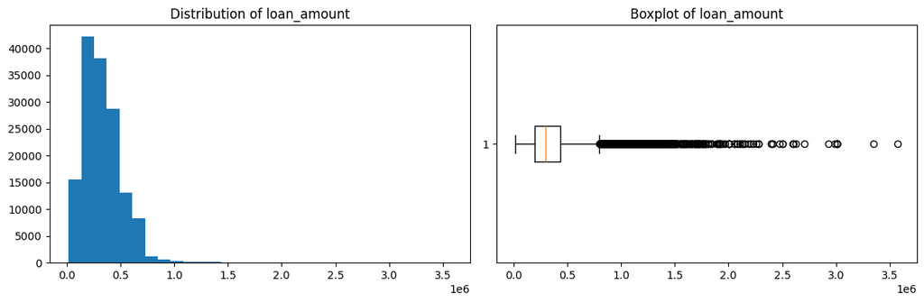

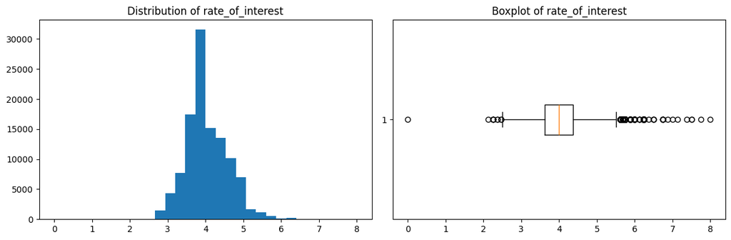

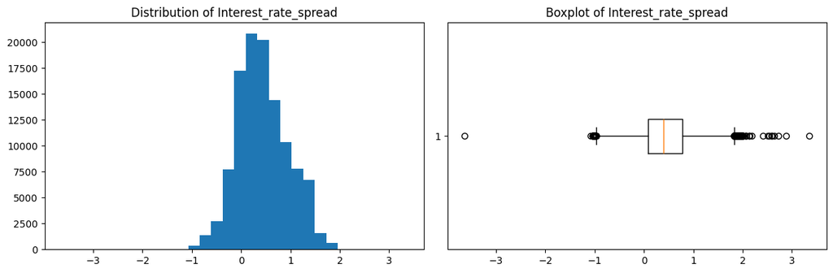

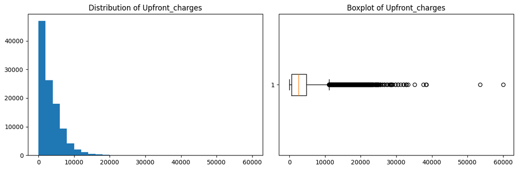

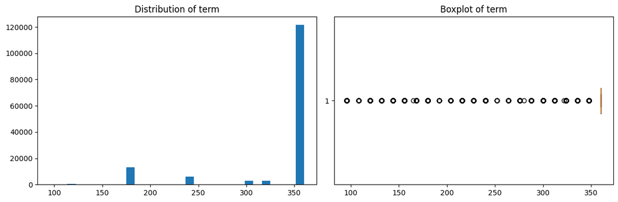

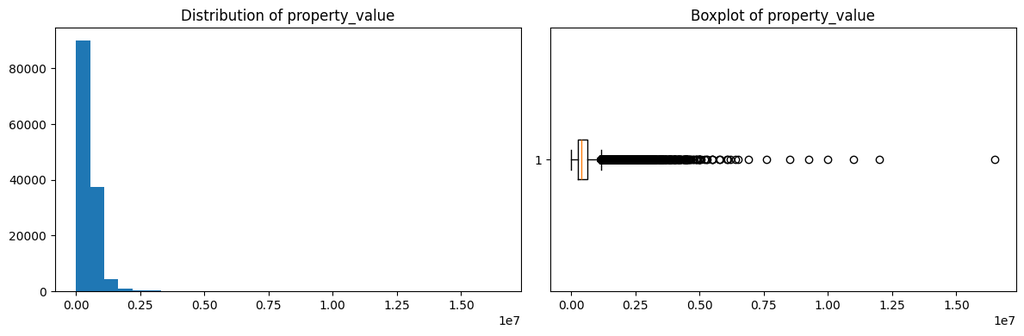

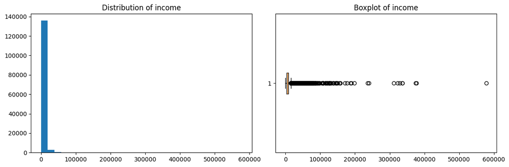

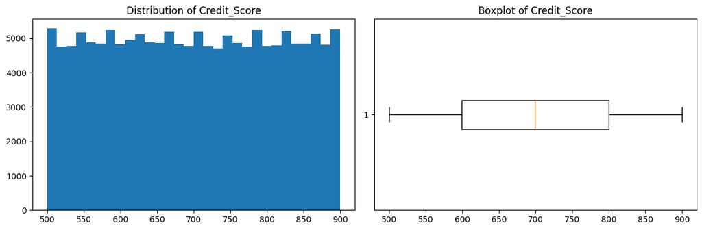

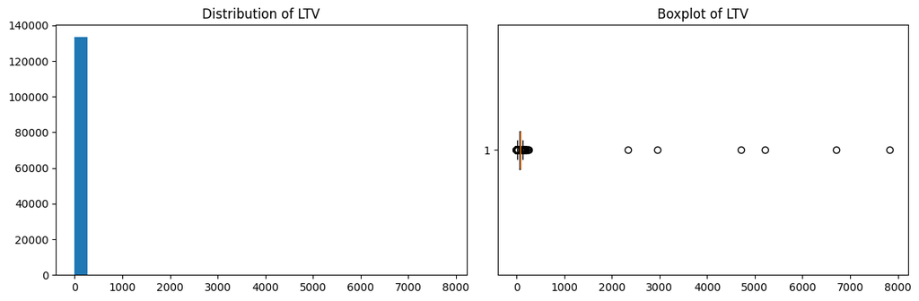

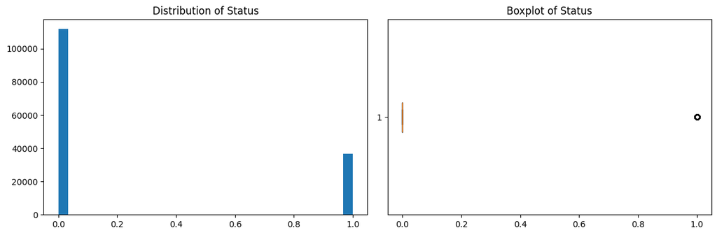

[1 more figures not shown]

```python
# ---- BOXPLOT FOR NUMERICAL VARIABLES ----
#dist on numerical columns with missing values:
for col in num_cols:
    plt.figure(figsize=(12,4))

    plt.subplot(1,2,1)
    plt.hist(df[col].dropna(), bins=30)
    plt.title(f"Distribution of {col}")

    plt.subplot(1,2,2)
    plt.boxplot(df[col].dropna(), vert=False)
    plt.title(f"Boxplot of {col}")

    plt.tight_layout()
    plt.show()
```

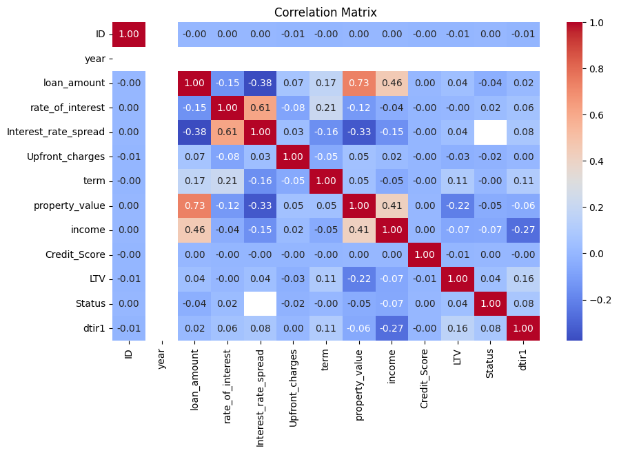

```python
plt.figure(figsize=(10,6))
# Calculate correlation matrix only for numerical columns in the DataFrame
sns.heatmap(df[num_cols].corr(), annot=True, fmt=".2f", cmap='coolwarm', annot_kws={"size": 10})
plt.title("Correlation Matrix")
plt.show()
# Most of the correlation between status and numerical vars are very low.
```

```python
df_corr = df.copy()
# convert to categorical codes
for col in cat_cols:
    df_corr[col] = df_corr[col].astype('category').cat.codes

# compute correlation of each var vs Status
corrs = df_corr[cat_cols].corrwith(df_corr['Status']).sort_values(ascending=True)
print(corrs)
```

```
lump_sum_payment            -0.19
Neg_ammortization           -0.15
business_or_commercial      -0.09
approv_in_adv               -0.04
loan_purpose                -0.03
construction_type           -0.03
occupancy_type              -0.02
interest_only               -0.01
open_credit                 -0.01
total_units                  0.02
Secured_by                   0.03
Security_Type                0.03
Region                       0.03
Credit_Worthiness            0.03
loan_limit                   0.04
age                          0.04
Gender                       0.05
loan_type                    0.05
submission_of_application    0.11
credit_type                  0.11
co_applicant_credit_type     0.14
dtype: float64
```

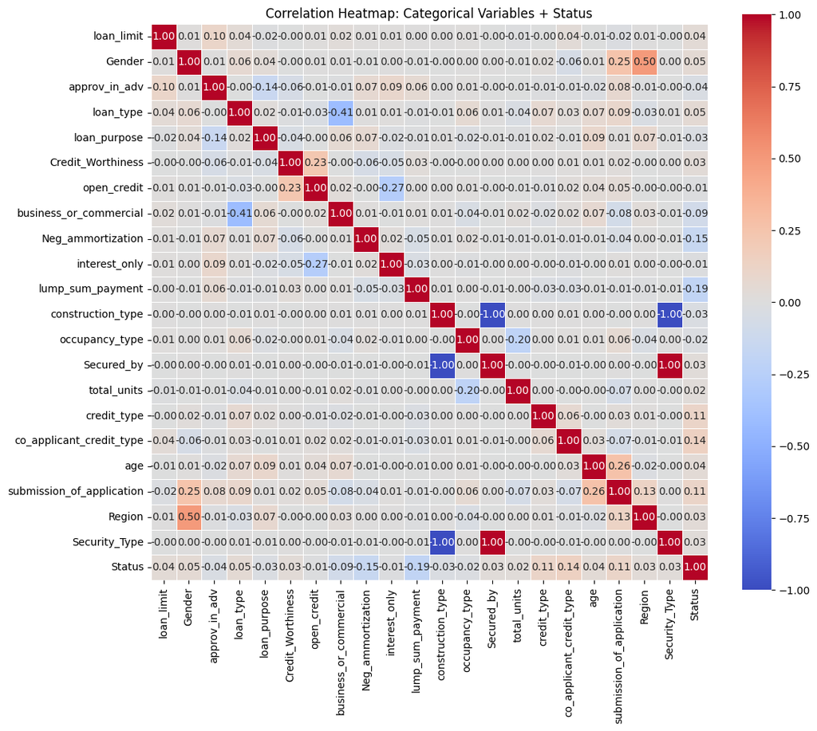

```python
df_corr = df.copy()

# Convert categorical variables to numerical codes
for col in cat_cols:
    df_corr[col] = df_corr[col].astype('category').cat.codes

# Include Status in the correlation matrix
columns_to_corr = cat_cols + ['Status']
corr_matrix = df_corr[columns_to_corr].corr()

# Plot heatmap with 2 decimals
plt.figure(figsize=(12, 10))
sns.heatmap(
    corr_matrix,
    annot=True,          # show correlation values
    fmt=".2f",           # 2 decimals
    cmap="coolwarm",
    linewidths=0.5,
    square=True
)
plt.title("Correlation Heatmap: Categorical Variables + Status")
plt.show()
```

### **Preliminar Exploratory Analysis Insights**

```python
df_clean = df.copy()
```

```python
# First, basic missingness:
missing_counts = df.isna().sum()
missing_pct = df.isna().mean() * 100

missing_summary = pd.DataFrame({
    'missing_count': missing_counts,
    'missing_pct': missing_pct
}).sort_values(by='missing_pct', ascending=False)

print("=== Overall missingness per variable ===")
print(missing_summary)


# Now, missingness by class (Status = 0 vs 1) for each column
results = []

for col in df.columns:
    if df[col].isna().sum() == 0 or col == 'Status':
        continue

    # indicator of missingness
    miss_ind = df[col].isna().astype(int)

    # total missing
    total_missing = miss_ind.sum()
    total_pct = total_missing / len(df) * 100

    # missingness by Status
    group = df.groupby('Status')[col].apply(lambda x: x.isna().sum())
    # counts of each class
    class_counts = df['Status'].value_counts()

    missing_0 = group.get(0, 0)
    missing_1 = group.get(1, 0)

    pct_missing_0_within_class0 = missing_0 / class_counts.get(0, 1) * 100
    pct_missing_1_within_class1 = missing_1 / class_counts.get(1, 1) * 100

    # proportion of all missing that belong to each class
    share_missing_from_0 = missing_0 / total_missing  * 100 if total_missing > 0 else np.nan
    share_missing_from_1 = missing_1 / total_missing  * 100 if total_missing > 0 else np.nan

    results.append({
        'variable': col,
        'total_missing': total_missing,
        'total_missing_pct': total_pct,
        '%class0_missing_within_class0': pct_missing_0_within_class0,
        '%class1_missing_within_class1': pct_missing_1_within_class1,
        'share_missing_from_class0': share_missing_from_0,
        'share_missing_from_class1': share_missing_from_1
    })

missing_by_class = pd.DataFrame(results).sort_values(
    by='total_missing_pct', ascending=False
)

print("\n=== Missingness profile by variable and by Status ===")
missing_by_class
```

```
=== Overall missingness per variable ===
                           missing_count  missing_pct
Upfront_charges                    39642        26.66
Interest_rate_spread               36639        24.64
rate_of_interest                   36439        24.51
dtir1                              24121        16.22
property_value                     15098        10.16
LTV                                15098        10.16
income                              9150         6.15
loan_limit                          3344         2.25
approv_in_adv                        908         0.61
age                                  200         0.13
submission_of_application            200         0.13
loan_purpose                         134         0.09
Neg_ammortization                    121         0.08
term                                  41         0.03
year                                   0         0.00
ID                                     0         0.00
business_or_commercial                 0         0.00
open_credit                            0         0.00
lump_sum_payment                       0         0.00
interest_only                          0         0.00
loan_amount                            0         0.00
Gender                                 0         0.00
loan_type                              0         0.00
Credit_Worthiness                      0         0.00
occupancy_type                         0         0.00
construction_type                      0         0.00
Credit_Score                           0         0.00
credit_type                            0         0.00
total_units                            0         0.00
Secured_by                             0         0.00
co_applicant_credit_type               0         0.00
Region                                 0         0.00
Security_Type                          0         0.00
Status                                 0         0.00

=== Missingness profile by variable and by Status ===
```

|  | variable | total_missing | total_missing_pct | %class0_missing_within_class0 | %class1_missing_within_class1 | share_missing_from_class0 | share_missing_from_class1 |
| --- | --- | --- | --- | --- | --- | --- | --- |
| 5 | Upfront_charges | 39642 | 26.66 | 2.82 | 99.58 | 7.96 | 92.04 |
| 4 | Interest_rate_spread | 36639 | 24.64 | 0.00 | 100.00 | 0.00 | 100.00 |
| 3 | rate_of_interest | 36439 | 24.51 | 0.00 | 99.45 | 0.00 | 100.00 |
| 13 | dtir1 | 24121 | 16.22 | 6.97 | 44.52 | 32.38 | 67.62 |
| 8 | property_value | 15098 | 10.16 | 0.00 | 41.20 | 0.01 | 99.99 |
| 12 | LTV | 15098 | 10.16 | 0.00 | 41.20 | 0.01 | 99.99 |
| 9 | income | 9150 | 6.15 | 7.06 | 3.38 | 86.46 | 13.54 |
| 0 | loan_limit | 3344 | 2.25 | 2.20 | 2.40 | 73.65 | 26.35 |
| 1 | approv_in_adv | 908 | 0.61 | 0.60 | 0.66 | 73.46 | 26.54 |
| 11 | submission_of_application | 200 | 0.13 | 0.00 | 0.55 | 0.00 | 100.00 |
| 10 | age | 200 | 0.13 | 0.00 | 0.55 | 0.00 | 100.00 |
| 2 | loan_purpose | 134 | 0.09 | 0.09 | 0.10 | 73.88 | 26.12 |
| 7 | Neg_ammortization | 121 | 0.08 | 0.08 | 0.09 | 73.55 | 26.45 |
| 6 | term | 41 | 0.03 | 0.02 | 0.04 | 63.41 | 36.59 |

Missingness is largely informative and concentrated in defaulted loans, making naïve imputation or row deletion inappropriate. A variable-specific, leakage-free preprocessing strategy is applied to preserve predictive signal and respect class imbalance.

```python
# Variables where it is safe to drop missing rows
safe_drop_vars = [
    'approv_in_adv',
    'age',
    'submission_of_application',
    'loan_purpose',
    'Neg_ammortization',
    'term'
]

df_pre = df_clean.dropna(subset=safe_drop_vars).drop(columns=['ID', 'year', 'construction_type', 'Secured_by']) # Dropping 'ID' and 'year' as they are  irrelevant for the prediction task, and 'construction_type' and 'Secured_by' because of the perfect correlation between both and 'Security_Type')
print(df_pre.shape)
df_pre['Status'].value_counts(normalize=True)
```

```
(147274, 30)
```

| Status | proportion |
| --- | --- |
| 0 | 0.75 |
| 1 | 0.25 |

**dtype:** float64

```python
# Also need to drop those features from the cat features list
# Redundant features to drop
redundant_features = ['construction_type', 'Secured_by']
# Remove them from cat_cols
cat_cols = [col for col in cat_cols if col not in redundant_features]
```

```python
from sklearn.model_selection import train_test_split

X = df_pre.drop('Status', axis=1)
y = df_pre['Status']

X_train, X_test, y_train, y_test = train_test_split(
    X, y,
    test_size=0.2,
    random_state=42,
    stratify=y
)

print(X_train.shape, X_test.shape)
print(y_train.mean(), y_test.mean())
```

```
(117819, 29) (29455, 29)
0.24528301886792453 0.2452894245459175
```

Numeric variables show structurally informative missingness concentrated in defaulted loans, so naïve imputation or row deletion would bias the data and hide predictive signal. A variable-specific, hierarchical median imputation strategy is applied using relevant loan and property characteristics, fitted only on training data, with missingness indicators added to preserve risk information and prevent leakage.

### **Grouping Numerical Features Intuition**

This grouping strategy ensures that missingness and distributional patterns are interpreted in line with the economic and underwriting logic, preserving predictive signal, supporting robust IFRS-compliant credit-risk modeling, and avoiding arbitrary statistical assumptions.

```python
var = 'rate_of_interest'
group_vars = ['loan_type', 'loan_purpose', 'loan_limit', 'business_or_commercial']

# 1. Look at counts by group
group_counts = X_train[~X_train[var].isna()].groupby(group_vars)[var].size().reset_index(name='n')
print(group_counts.sort_values('n', ascending=False).head(20))

# 2. Look at medians by group
group_medians = X_train[~X_train[var].isna()].groupby(group_vars)[var].median().reset_index(name='median')
group_medians.head(20)
```

```
   loan_type loan_purpose loan_limit business_or_commercial      n
6      type1           p4         cf                  nob/c  24766
4      type1           p3         cf                  nob/c  23565
0      type1           p1         cf                  nob/c  14176
12     type2           p3         cf                    b/c   4076
21     type3           p4         cf                  nob/c   3489
14     type2           p4         cf                    b/c   2987
19     type3           p3         cf                  nob/c   2965
8      type2           p1         cf                    b/c   2784
2      type1           p2         cf                  nob/c   1428
5      type1           p3        ncf                  nob/c   1321
7      type1           p4        ncf                  nob/c   1248
16     type3           p1         cf                  nob/c   1213
1      type1           p1        ncf                  nob/c   1172
22     type3           p4        ncf                  nob/c    469
20     type3           p3        ncf                  nob/c    322
13     type2           p3        ncf                    b/c    229
17     type3           p1        ncf                  nob/c    224
9      type2           p1        ncf                    b/c    190
10     type2           p2         cf                    b/c    164
15     type2           p4        ncf                    b/c     82
```

|  | loan_type | loan_purpose | loan_limit | business_or_commercial | median |
| --- | --- | --- | --- | --- | --- |
| 0 | type1 | p1 | cf | nob/c | 4.18 |
| 1 | type1 | p1 | ncf | nob/c | 4.25 |
| 2 | type1 | p2 | cf | nob/c | 4.62 |
| 3 | type1 | p2 | ncf | nob/c | 4.56 |
| 4 | type1 | p3 | cf | nob/c | 4.12 |
| 5 | type1 | p3 | ncf | nob/c | 4.38 |
| 6 | type1 | p4 | cf | nob/c | 3.88 |
| 7 | type1 | p4 | ncf | nob/c | 4.00 |
| 8 | type2 | p1 | cf | b/c | 3.99 |
| 9 | type2 | p1 | ncf | b/c | 4.12 |
| 10 | type2 | p2 | cf | b/c | 4.12 |
| 11 | type2 | p2 | ncf | b/c | 3.99 |
| 12 | type2 | p3 | cf | b/c | 3.99 |
| 13 | type2 | p3 | ncf | b/c | 4.12 |
| 14 | type2 | p4 | cf | b/c | 3.62 |
| 15 | type2 | p4 | ncf | b/c | 3.99 |
| 16 | type3 | p1 | cf | nob/c | 3.88 |
| 17 | type3 | p1 | ncf | nob/c | 3.75 |
| 18 | type3 | p2 | cf | nob/c | 3.75 |
| 19 | type3 | p3 | cf | nob/c | 3.75 |

```python
var = 'Interest_rate_spread'
group_vars = ['loan_type', 'loan_purpose', 'loan_limit', 'business_or_commercial']

# 1. Look at counts by group
group_counts = X_train[~X_train[var].isna()].groupby(group_vars)[var].size().reset_index(name='n')
print(group_counts.sort_values('n', ascending=False).head(20))

# 2. Look at medians by group
group_medians = X_train[~X_train[var].isna()].groupby(group_vars)[var].median().reset_index(name='median')
group_medians.head(20)
```

```
   loan_type loan_purpose loan_limit business_or_commercial      n
6      type1           p4         cf                  nob/c  24766
4      type1           p3         cf                  nob/c  23565
0      type1           p1         cf                  nob/c  14176
12     type2           p3         cf                    b/c   4076
21     type3           p4         cf                  nob/c   3489
14     type2           p4         cf                    b/c   2987
19     type3           p3         cf                  nob/c   2965
8      type2           p1         cf                    b/c   2784
2      type1           p2         cf                  nob/c   1428
5      type1           p3        ncf                  nob/c   1321
7      type1           p4        ncf                  nob/c   1248
16     type3           p1         cf                  nob/c   1213
1      type1           p1        ncf                  nob/c   1172
22     type3           p4        ncf                  nob/c    469
20     type3           p3        ncf                  nob/c    322
13     type2           p3        ncf                    b/c    229
17     type3           p1        ncf                  nob/c    224
9      type2           p1        ncf                    b/c    190
10     type2           p2         cf                    b/c    164
15     type2           p4        ncf                    b/c     82
```

|  | loan_type | loan_purpose | loan_limit | business_or_commercial | median |
| --- | --- | --- | --- | --- | --- |
| 0 | type1 | p1 | cf | nob/c | 0.35 |
| 1 | type1 | p1 | ncf | nob/c | 0.33 |
| 2 | type1 | p2 | cf | nob/c | 0.92 |
| 3 | type1 | p2 | ncf | nob/c | 1.02 |
| 4 | type1 | p3 | cf | nob/c | 0.51 |
| 5 | type1 | p3 | ncf | nob/c | 0.52 |
| 6 | type1 | p4 | cf | nob/c | 0.21 |
| 7 | type1 | p4 | ncf | nob/c | 0.20 |
| 8 | type2 | p1 | cf | b/c | 1.12 |
| 9 | type2 | p1 | ncf | b/c | 1.21 |
| 10 | type2 | p2 | cf | b/c | 1.32 |
| 11 | type2 | p2 | ncf | b/c | 0.82 |
| 12 | type2 | p3 | cf | b/c | 1.00 |
| 13 | type2 | p3 | ncf | b/c | 0.99 |
| 14 | type2 | p4 | cf | b/c | 0.80 |
| 15 | type2 | p4 | ncf | b/c | 0.96 |
| 16 | type3 | p1 | cf | nob/c | 0.06 |
| 17 | type3 | p1 | ncf | nob/c | -0.10 |
| 18 | type3 | p2 | cf | nob/c | 0.73 |
| 19 | type3 | p3 | cf | nob/c | 0.18 |

```python
var = 'property_value'
group_vars = ['Region', 'occupancy_type', 'business_or_commercial', 'total_units']

# 1. Look at counts by group
group_counts = X_train[~X_train[var].isna()].groupby(group_vars)[var].size().reset_index(name='n')
print(group_counts.sort_values('n', ascending=False).head(20))

# 2. Look at medians by group
group_medians = X_train[~X_train[var].isna()].groupby(group_vars)[var].median().reset_index(name='median')
group_medians.head(20)
```

```
        Region occupancy_type business_or_commercial total_units      n
19       north             pr                  nob/c          1u  42510
41       south             pr                  nob/c          1u  35546
16       north             pr                    b/c          1u   7243
38       south             pr                    b/c          1u   5715
7      central             pr                  nob/c          1u   4487
34       south             ir                  nob/c          1u   2372
12       north             ir                  nob/c          1u   1872
24       north             sr                  nob/c          1u   1271
4      central             pr                    b/c          1u   1258
46       south             sr                  nob/c          1u    829
30  north-east             pr                  nob/c          1u    658
20       north             pr                  nob/c          2u    303
0      central             ir                  nob/c          1u    231
42       south             pr                  nob/c          2u    215
13       north             ir                  nob/c          2u    165
35       south             ir                  nob/c          2u    165
28  north-east             pr                    b/c          1u    159
11     central             sr                  nob/c          1u    101
37       south             ir                  nob/c          4u     83
14       north             ir                  nob/c          3u     81
```

|  | Region | occupancy_type | business_or_commercial | total_units | median |
| --- | --- | --- | --- | --- | --- |
| 0 | central | ir | nob/c | 1u | 408000.00 |
| 1 | central | ir | nob/c | 2u | 558000.00 |
| 2 | central | ir | nob/c | 3u | 618000.00 |
| 3 | central | ir | nob/c | 4u | 688000.00 |
| 4 | central | pr | b/c | 1u | 268000.00 |
| 5 | central | pr | b/c | 2u | 563000.00 |
| 6 | central | pr | b/c | 3u | 308000.00 |
| 7 | central | pr | nob/c | 1u | 428000.00 |
| 8 | central | pr | nob/c | 2u | 578000.00 |
| 9 | central | pr | nob/c | 3u | 1208000.00 |
| 10 | central | pr | nob/c | 4u | 1058000.00 |
| 11 | central | sr | nob/c | 1u | 278000.00 |
| 12 | north | ir | nob/c | 1u | 398000.00 |
| 13 | north | ir | nob/c | 2u | 598000.00 |
| 14 | north | ir | nob/c | 3u | 798000.00 |
| 15 | north | ir | nob/c | 4u | 953000.00 |
| 16 | north | pr | b/c | 1u | 268000.00 |
| 17 | north | pr | b/c | 2u | 508000.00 |
| 18 | north | pr | b/c | 3u | 958000.00 |
| 19 | north | pr | nob/c | 1u | 448000.00 |

```python
var = 'LTV'
group_vars = ['Region', 'occupancy_type', 'business_or_commercial', 'total_units']

# 1. Look at counts by group
group_counts = X_train[~X_train[var].isna()].groupby(group_vars)[var].size().reset_index(name='n')
print(group_counts.sort_values('n', ascending=False).head(20))

# 2. Look at medians by group
group_medians = X_train[~X_train[var].isna()].groupby(group_vars)[var].median().reset_index(name='median')
group_medians.head(20)
```

```
        Region occupancy_type business_or_commercial total_units      n
19       north             pr                  nob/c          1u  42510
41       south             pr                  nob/c          1u  35546
16       north             pr                    b/c          1u   7243
38       south             pr                    b/c          1u   5715
7      central             pr                  nob/c          1u   4487
34       south             ir                  nob/c          1u   2372
12       north             ir                  nob/c          1u   1872
24       north             sr                  nob/c          1u   1271
4      central             pr                    b/c          1u   1258
46       south             sr                  nob/c          1u    829
30  north-east             pr                  nob/c          1u    658
20       north             pr                  nob/c          2u    303
0      central             ir                  nob/c          1u    231
42       south             pr                  nob/c          2u    215
13       north             ir                  nob/c          2u    165
35       south             ir                  nob/c          2u    165
28  north-east             pr                    b/c          1u    159
11     central             sr                  nob/c          1u    101
37       south             ir                  nob/c          4u     83
14       north             ir                  nob/c          3u     81
```

|  | Region | occupancy_type | business_or_commercial | total_units | median |
| --- | --- | --- | --- | --- | --- |
| 0 | central | ir | nob/c | 1u | 69.93 |
| 1 | central | ir | nob/c | 2u | 68.03 |
| 2 | central | ir | nob/c | 3u | 60.10 |
| 3 | central | ir | nob/c | 4u | 66.79 |
| 4 | central | pr | b/c | 1u | 88.57 |
| 5 | central | pr | b/c | 2u | 97.08 |
| 6 | central | pr | b/c | 3u | 21.59 |
| 7 | central | pr | nob/c | 1u | 76.73 |
| 8 | central | pr | nob/c | 2u | 72.15 |
| 9 | central | pr | nob/c | 3u | 52.69 |
| 10 | central | pr | nob/c | 4u | 74.21 |
| 11 | central | sr | nob/c | 1u | 81.25 |
| 12 | north | ir | nob/c | 1u | 68.23 |
| 13 | north | ir | nob/c | 2u | 65.50 |
| 14 | north | ir | nob/c | 3u | 62.96 |
| 15 | north | ir | nob/c | 4u | 69.76 |
| 16 | north | pr | b/c | 1u | 86.95 |
| 17 | north | pr | b/c | 2u | 91.83 |
| 18 | north | pr | b/c | 3u | 93.58 |
| 19 | north | pr | nob/c | 1u | 74.33 |

```python
var = 'dtir1'
group_vars = ['loan_type', 'business_or_commercial', 'occupancy_type']

# 1. Look at counts by group
group_counts = X_train[~X_train[var].isna()].groupby(group_vars)[var].size().reset_index(name='n')
print(group_counts.sort_values('n', ascending=False).head(20))

# 2. Look at medians by group
group_medians = X_train[~X_train[var].isna()].groupby(group_vars)[var].median().reset_index(name='median')
group_medians.head(20)
```

```
  loan_type business_or_commercial occupancy_type      n
1     type1                  nob/c             pr  73535
4     type2                    b/c             pr  11779
6     type3                  nob/c             pr   6043
0     type1                  nob/c             ir   5199
2     type1                  nob/c             sr   2212
3     type2                    b/c             ir      2
5     type2                    b/c             sr      2
```

|  | loan_type | business_or_commercial | occupancy_type | median |
| --- | --- | --- | --- | --- |
| 0 | type1 | nob/c | ir | 39.00 |
| 1 | type1 | nob/c | pr | 38.00 |
| 2 | type1 | nob/c | sr | 38.00 |
| 3 | type2 | b/c | ir | 43.00 |
| 4 | type2 | b/c | pr | 44.00 |
| 5 | type2 | b/c | sr | 40.00 |
| 6 | type3 | nob/c | pr | 42.00 |

```python
var = 'income'
group_vars = ['Region', 'business_or_commercial', 'occupancy_type']

# 1. Look at counts by group
group_counts = X_train[~X_train[var].isna()].groupby(group_vars)[var].size().reset_index(name='n')
print(group_counts.sort_values('n', ascending=False).head(20))

# 2. Look at medians by group
group_medians = X_train[~X_train[var].isna()].groupby(group_vars)[var].median().reset_index(name='median')
group_medians.head(20)
```

```
        Region business_or_commercial occupancy_type      n
7        north                  nob/c             pr  45289
17       south                  nob/c             pr  38093
4        north                    b/c             pr   6844
14       south                    b/c             pr   5374
2      central                  nob/c             pr   4687
16       south                  nob/c             ir   3004
6        north                  nob/c             ir   2416
8        north                  nob/c             sr   1414
0      central                    b/c             pr   1228
18       south                  nob/c             sr    927
11  north-east                  nob/c             pr    701
1      central                  nob/c             ir    321
9   north-east                    b/c             pr    159
3      central                  nob/c             sr    113
10  north-east                  nob/c             ir     48
12  north-east                  nob/c             sr     11
13       south                    b/c             ir      2
5        north                    b/c             sr      1
15       south                    b/c             sr      1
```

|  | Region | business_or_commercial | occupancy_type | median |
| --- | --- | --- | --- | --- |
| 0 | central | b/c | pr | 3900.00 |
| 1 | central | nob/c | ir | 7620.00 |
| 2 | central | nob/c | pr | 5760.00 |
| 3 | central | nob/c | sr | 9120.00 |
| 4 | north | b/c | pr | 4080.00 |
| 5 | north | b/c | sr | 4020.00 |
| 6 | north | nob/c | ir | 7920.00 |
| 7 | north | nob/c | pr | 5820.00 |
| 8 | north | nob/c | sr | 9600.00 |
| 9 | north-east | b/c | pr | 3780.00 |
| 10 | north-east | nob/c | ir | 7170.00 |
| 11 | north-east | nob/c | pr | 4980.00 |
| 12 | north-east | nob/c | sr | 7200.00 |
| 13 | south | b/c | ir | 3240.00 |
| 14 | south | b/c | pr | 3900.00 |
| 15 | south | b/c | sr | 6420.00 |
| 16 | south | nob/c | ir | 8670.00 |
| 17 | south | nob/c | pr | 5880.00 |
| 18 | south | nob/c | sr | 9660.00 |

Detailed analysis shows that numeric variables with missing values (e.g., `rate_of_interest`, `Interest_rate_spread`, `property_value`, `LTV`, `dtir1`, `income`) are strongly structured by loan product, borrower profile, and collateral characteristics. Medians differ sharply across meaningful groups, reflecting underwriting, pricing, and regional patterns rather than random noise. Using a single global statistic would collapse these distinct economic strata, misrepresent risk, and bias imputed values. Therefore, hierarchical group-wise median imputation with missingness indicators is applied, fitted only on the training set, preserving heterogeneity, predictive signal, and a leakage-free pipeline consistent with IFRS-compliant credit-risk modeling.

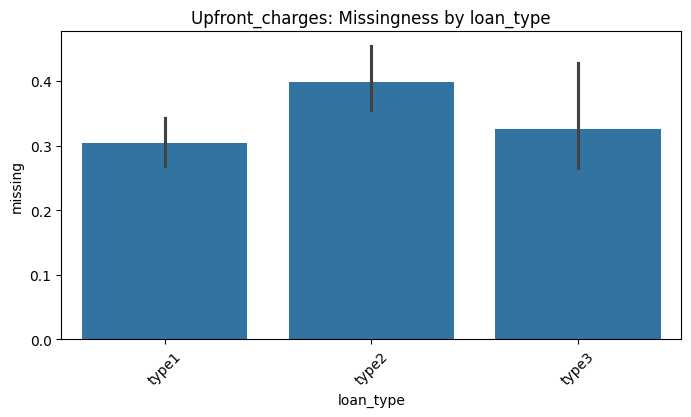

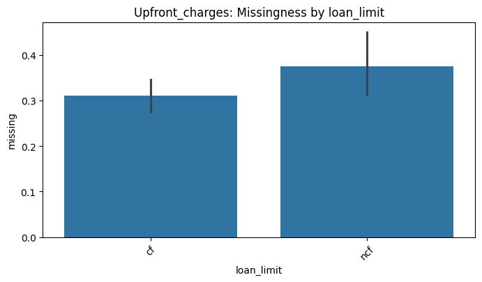

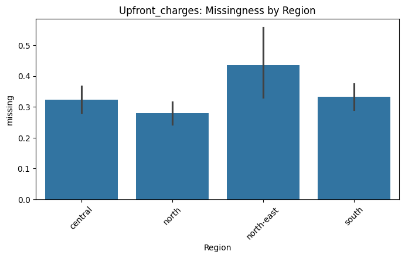

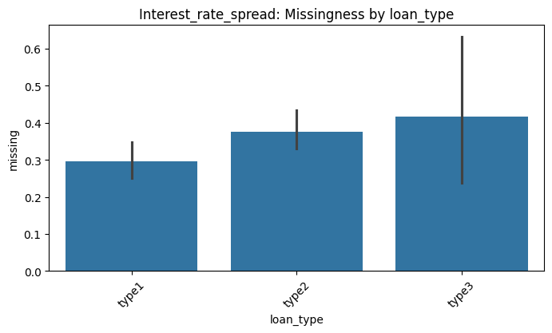

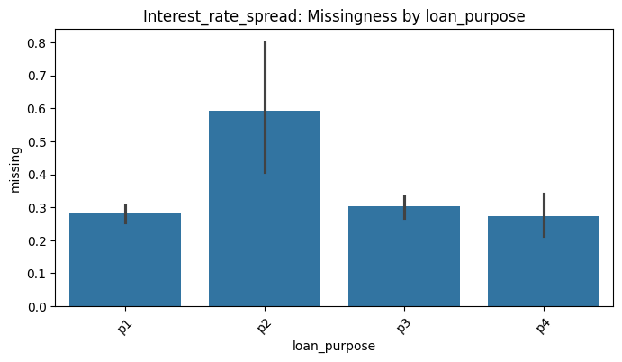

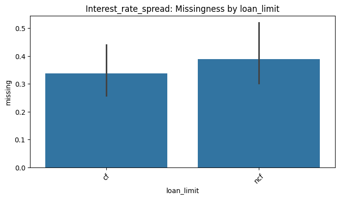

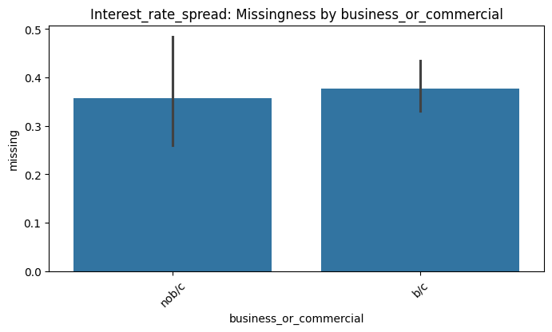

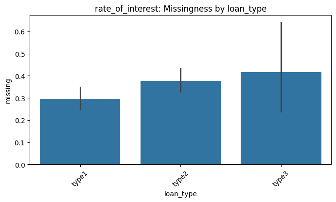

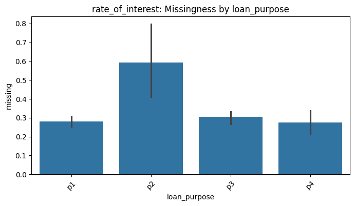

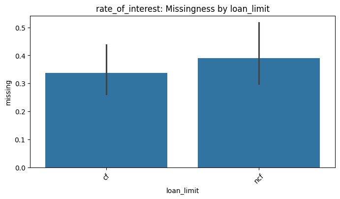

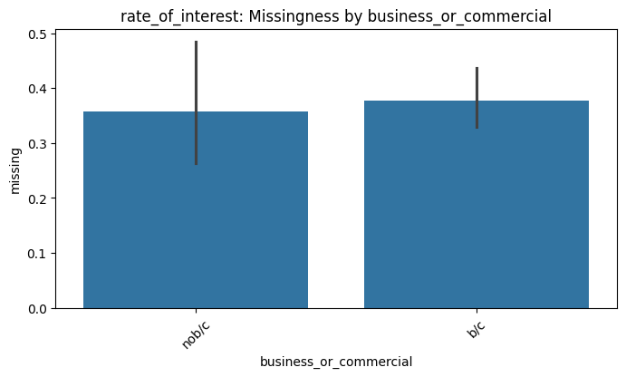

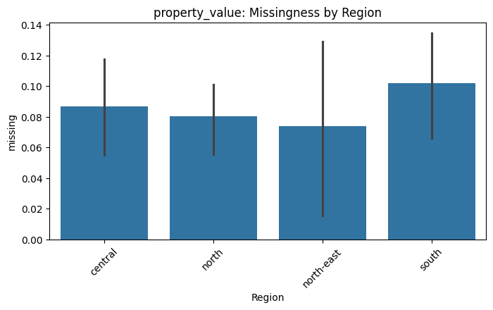

[13 more figures not shown]

```python
num_vars = [
    'Upfront_charges',
    'Interest_rate_spread',
    'rate_of_interest',
    'property_value',
    'LTV',
    'dtir1',
    'income'
]

grouping_sets = {
    'rate_of_interest': ['loan_type', 'loan_purpose', 'loan_limit', 'business_or_commercial'],
    'Interest_rate_spread': ['loan_type', 'loan_purpose', 'loan_limit', 'business_or_commercial'],
    'Upfront_charges': ['loan_type', 'loan_limit', 'Region'],
    'property_value': ['Region', 'occupancy_type', 'business_or_commercial', 'total_units'],
    'LTV': ['Region', 'occupancy_type', 'business_or_commercial', 'total_units'],
    'dtir1': ['loan_type', 'business_or_commercial', 'occupancy_type'],
    'income': ['Region', 'business_or_commercial', 'occupancy_type']
}

for var in num_vars:
    groups = grouping_sets[var]

    # create missingness indicator and group by all grouping vars
    missing_grp = (
        X_train.assign(missing = X_train[var].isna().astype(int))
                .groupby(groups)['missing']
                .mean()
                .reset_index()
    )

    # Plt for each group dimension separately
    for g in groups:
        plt.figure(figsize=(8,4))
        sns.barplot(data=missing_grp, x=g, y='missing')
        plt.title(f"{var}: Missingness by {g}")
        plt.xticks(rotation=45)
        plt.show()
```

Missing values in this dataset are highly structured and informative, concentrated in key numeric variables: `Upfront_charges` (27%), `rate_of_interest` and `Interest_rate_spread` (25%), `dtir1` (16%), `property_value` and `LTV` (10%), and `income` (6%). Most missingness occurs in defaulted loans, indicating that “being missing” itself carries predictive signal. Patterns are systematically linked to product design, loan type, purpose, limit, business/commercial classification, occupancy, region, and property characteristics. Group-median diagnostics show stable and economically interpretable differences across these segments, supporting hierarchical group-wise median imputation with missingness indicators rather than global statistics. This approach preserves heterogeneity, reflects underwriting and collateral logic, and maintains a leakage-free pipeline.

### **Categorical Missing Values Grouping Analysis**

```python
X_train.info()
```

```
<class 'pandas.core.frame.DataFrame'>
Index: 117819 entries, 50589 to 124434
Data columns (total 29 columns):
 #   Column                     Non-Null Count   Dtype
---  ------                     --------------   -----
 0   loan_limit                 115170 non-null  object
 1   Gender                     117819 non-null  object
 2   approv_in_adv              117819 non-null  object
 3   loan_type                  117819 non-null  object
 4   loan_purpose               117819 non-null  object
 5   Credit_Worthiness          117819 non-null  object
 6   open_credit                117819 non-null  object
 7   business_or_commercial     117819 non-null  object
 8   loan_amount                117819 non-null  int64
 9   rate_of_interest           88920 non-null   float64
```

[output cut: 21 more lines]

```python
tmp = X_train.copy()
tmp['Status'] = y_train
cat_cols_missing = [c for c in cat_cols if X_train[c].isna().sum() > 0]
cat_cols_missing
cat_missing = (
    X_train[cat_cols]
        .isna()
        .mean()
        .sort_values(ascending=False)
        .to_frame("missing_pct")
)

cat_missing
```

|  | missing_pct |
| --- | --- |
| loan_limit | 0.02 |
| Gender | 0.00 |
| approv_in_adv | 0.00 |
| loan_type | 0.00 |
| loan_purpose | 0.00 |
| Credit_Worthiness | 0.00 |
| open_credit | 0.00 |
| business_or_commercial | 0.00 |
| Neg_ammortization | 0.00 |
| interest_only | 0.00 |
| lump_sum_payment | 0.00 |
| occupancy_type | 0.00 |
| total_units | 0.00 |
| credit_type | 0.00 |
| co_applicant_credit_type | 0.00 |
| age | 0.00 |
| submission_of_application | 0.00 |
| Region | 0.00 |
| Security_Type | 0.00 |

```python
tmp = X_train.copy()
tmp['Status'] = y_train

cat_missing_status = (
    tmp.groupby("Status")[cat_cols_missing]
       .apply(lambda x: x.isna().mean())
       .T
)

cat_missing_status
```

| Status | 0 | 1 |
| --- | --- | --- |
| loan_limit | 0.02 | 0.02 |

A subset of features exhibits very low missingness (~2.25%) with similar distribution across default and non-default loans, indicating no systematic bias. Missingness appears random (MAR or MCAR), and mode imputation is sufficient for these variables, ensuring minimal impact on model stability.

### **Imputation Strategy for Numerical Variables**

Missingness in numeric variables is structurally driven, reflecting product design, collateral, geography, and underwriting rules. Global imputation would distort distributions and bias the model. Deterministic relationships are leveraged first (e.g., `LTV` = `loan_amount` / `property_value` × 100). Remaining variables are imputed hierarchically using medians within economically meaningful groups:

Pricing variables (`rate_of_interest`, `Interest_rate_spread`) by `loan_type`, `loan_purpose`, `loan_limit`, and business/commercial status.

`Upfront_charges` by `loan_type`, `loan_limit`, and `region`.

Collateral variables (`property_value`, `LTV`) by `region`, `occupancy_type`, `business_or_commercial`, and `total_units`.

Affordability variables (`dtir1`, `income`) by `loan_type`, `business_or_commercial`, and `occupancy_type`, with `income` imputed across regions due to low and balanced missingness. This variable-specific, domain-aware approach preserves predictive signal, respects economic and underwriting logic, and ensures a leakage-free preprocessing pipeline.

```python
#checking that groups are non-empty
Xtr = X_train.copy()
Xte = X_test.copy()

groups_rate = ['loan_type', 'loan_purpose', 'loan_limit', 'business_or_commercial']

group_counts_rate = (
    Xtr.groupby(groups_rate).size().reset_index(name='count')
)

print(group_counts_rate.sort_values('count').head(15))
groups_prop = ['Region', 'occupancy_type', 'business_or_commercial', 'total_units']

group_counts_prop = (
    Xtr.groupby(groups_prop).size().reset_index(name='count')
)

print(group_counts_prop.sort_values('count').head(15))
groups_dtir = ['loan_type', 'business_or_commercial', 'occupancy_type']
groups_inc  = ['Region', 'business_or_commercial', 'occupancy_type']

print(
    Xtr.groupby(groups_dtir).size().reset_index(name='count').sort_values('count').head(10)
)

print(
    Xtr.groupby(groups_inc).size().reset_index(name='count').sort_values('count').head(10)
)
```

```
   loan_type loan_purpose loan_limit business_or_commercial  count
19     type3           p2        ncf                  nob/c      1
18     type3           p2         cf                  nob/c      6
11     type2           p2        ncf                    b/c     13
15     type2           p4        ncf                    b/c    122
3      type1           p2        ncf                  nob/c    136
9      type2           p1        ncf                    b/c    278
17     type3           p1        ncf                  nob/c    296
10     type2           p2         cf                    b/c    313
13     type2           p3        ncf                    b/c    349
21     type3           p3        ncf                  nob/c    466
23     type3           p4        ncf                  nob/c    574
16     type3           p1         cf                  nob/c   1668
1      type1           p1        ncf                  nob/c   1707
5      type1           p3        ncf                  nob/c   1910
```

[output cut: 36 more lines]

```python
# We thought that maybe some of the groups had to few observations
# this would make that the median is meaningless so now the code is intended to start reducing the amount of features in groups until the number
# of observations is large enough to mean something 50 obs.
# =========================================================
# HELPER FUNCTIONS
# =========================================================

def hierarchical_impute_train(df, var, hier_groups, min_n=50):
    """
    Train-side hierarchical median imputation.
    Fills df[var] missing using hierarchical groups.
    """
    df = df.copy()

    for groups in hier_groups:

        # compute group sizes
        group_sizes = df.groupby(groups)[var].transform("count")

        # TRUE for rows belonging to large enough groups
        mask_valid = group_sizes >= min_n

        # compute medians only for sufficiently large groups
        med = (
            df.loc[mask_valid]
            .groupby(groups)[var]
            .median()
            .rename("fill")
        )

        # merge medians
        df = df.merge(med, on=groups, how="left")

        # fill missing
        df[var] = df[var].fillna(df["fill"])
        df = df.drop(columns=["fill"])

    # final global fallback
    df[var] = df[var].fillna(df[var].median())
    return df


def hierarchical_impute_test(df_test, df_train, var, hier_groups, min_n=50):
    """
    Test-set hierarchical imputation.
    Uses TRAIN medians ONLY. Never touches test to compute medians.
    """
    df_test = df_test.copy()

    for groups in hier_groups:
        # compute TRAIN medians
        med = (
            df_train.groupby(groups)[var]
            .median()
            .rename("fill")
        )

        # merge into TEST
        df_test = df_test.merge(med, on=groups, how="left")

        # fill missing
        df_test[var] = df_test[var].fillna(df_test["fill"])
        df_test = df_test.drop(columns=["fill"])

    # final fallback = TRAIN global median
    df_test[var] = df_test[var].fillna(df_train[var].median())
    return df_test


# =========================================================
# COPY TRAIN + TEST
# =========================================================

Xtr = X_train.copy()
Xte = X_test.copy()

# =========================================================
# 1. RECOMPUTE LTV (deterministic)
# =========================================================

def recompute_LTV(df):
    cond = df["property_value"].notna() & (df["property_value"] > 0)
    df.loc[cond, "LTV"] = 100 * df.loc[cond, "loan_amount"] / df.loc[cond, "property_value"]
    return df

Xtr = recompute_LTV(Xtr)
Xte = recompute_LTV(Xte)


# =========================================================
# 2. IMPUTE PROPERTY_VALUE
# =========================================================

groups_prop_h = [
    ['Region', 'occupancy_type', 'business_or_commercial', 'total_units'],
    ['Region', 'occupancy_type', 'business_or_commercial'],
    ['Region', 'occupancy_type'],
    ['Region']
]

Xtr = hierarchical_impute_train(Xtr, 'property_value', groups_prop_h)
Xte = hierarchical_impute_test(Xte, Xtr, 'property_value', groups_prop_h)


# =========================================================
# 3. IMPUTE LTV
# =========================================================

Xtr = hierarchical_impute_train(Xtr, 'LTV', groups_prop_h)
Xte = hierarchical_impute_test(Xte, Xtr, 'LTV', groups_prop_h)


# =========================================================
# 4. RATE VARIABLES (rate_of_interest, Interest_rate_spread)
# =========================================================

groups_rate_h = [
    ['loan_type', 'loan_purpose', 'loan_limit', 'business_or_commercial'],
    ['loan_type', 'loan_purpose', 'loan_limit'],
    ['loan_type', 'loan_purpose'],
    ['loan_type']
]

for var in ['rate_of_interest', 'Interest_rate_spread']:
    Xtr = hierarchical_impute_train(Xtr, var, groups_rate_h)
    Xte = hierarchical_impute_test(Xte, Xtr, var, groups_rate_h)


# =========================================================
# 5. UPFRONT_CHARGES
# =========================================================

groups_up_h = [
    ['loan_type', 'loan_limit', 'Region'],
    ['loan_type', 'loan_limit'],
    ['loan_type'],
]

Xtr = hierarchical_impute_train(Xtr, 'Upfront_charges', groups_up_h)
Xte = hierarchical_impute_test(Xte, Xtr, 'Upfront_charges', groups_up_h)


# =========================================================
# 6. DTIR
# =========================================================

groups_dtir_h = [
    ['loan_type', 'business_or_commercial', 'occupancy_type'],
    ['loan_type', 'business_or_commercial'],
    ['loan_type'],
]

Xtr = hierarchical_impute_train(Xtr, 'dtir1', groups_dtir_h)
Xte = hierarchical_impute_test(Xte, Xtr, 'dtir1', groups_dtir_h)


# =========================================================
# 7. INCOME
# =========================================================

groups_inc_h = [
    ['Region', 'business_or_commercial', 'occupancy_type'],
    ['Region', 'business_or_commercial'],
    ['Region'],
]

Xtr = hierarchical_impute_train(Xtr, 'income', groups_inc_h)
Xte = hierarchical_impute_test(Xte, Xtr, 'income', groups_inc_h)


# =========================================================
# FINAL MISSINGNESS CHECK
# =========================================================

vars_check = [
    'rate_of_interest', 'Interest_rate_spread', 'Upfront_charges',
    'property_value', 'LTV', 'dtir1', 'income'
]

print("\n=== Missingness after hierarchical imputation (TRAIN) ===")
print(Xtr[vars_check].isna().sum())

print("\n=== Missingness after hierarchical imputation (TEST) ===")
print(Xte[vars_check].isna().sum())
```

```
=== Missingness after hierarchical imputation (TRAIN) ===
rate_of_interest        0
Interest_rate_spread    0
Upfront_charges         0
property_value          0
LTV                     0
dtir1                   0
income                  0
dtype: int64

=== Missingness after hierarchical imputation (TEST) ===
rate_of_interest        0
Interest_rate_spread    0
Upfront_charges         0
property_value          0
LTV                     0
dtir1                   0
income                  0
dtype: int64
```

```python
Xte.isna().sum()
# passing info from train to test is not wrong so this is fine!!
```

|  | 0 |
| --- | --- |
| loan_limit | 683 |
| Gender | 0 |
| approv_in_adv | 0 |
| loan_type | 0 |
| loan_purpose | 0 |
| Credit_Worthiness | 0 |
| open_credit | 0 |
| business_or_commercial | 0 |
| loan_amount | 0 |
| rate_of_interest | 0 |
| Interest_rate_spread | 0 |
| Upfront_charges | 0 |
| term | 0 |
| Neg_ammortization | 0 |
| interest_only | 0 |
| lump_sum_payment | 0 |
| property_value | 0 |
| occupancy_type | 0 |
| total_units | 0 |
| income | 0 |
| credit_type | 0 |
| Credit_Score | 0 |
| co_applicant_credit_type | 0 |
| age | 0 |
| submission_of_application | 0 |
| LTV | 0 |
| Region | 0 |
| Security_Type | 0 |
| dtir1 | 0 |

**dtype:** int64

```python
# LAST STEP: IMPUTE CATEGORICAL loan_limit
# ========================================

# compute mode ONLY ON TRAIN
mode_loan_limit = Xtr['loan_limit'].mode()[0]

# apply to train and test
Xtr['loan_limit'] = Xtr['loan_limit'].fillna(mode_loan_limit)
Xte['loan_limit'] = Xte['loan_limit'].fillna(mode_loan_limit)

# final missingness check
print(Xtr.isna().sum())
print(Xte.isna().sum())
```

```
loan_limit                   0
Gender                       0
approv_in_adv                0
loan_type                    0
loan_purpose                 0
Credit_Worthiness            0
open_credit                  0
business_or_commercial       0
loan_amount                  0
rate_of_interest             0
Interest_rate_spread         0
Upfront_charges              0
term                         0
Neg_ammortization            0
interest_only                0
lump_sum_payment             0
property_value               0
occupancy_type               0
total_units                  0
income                       0
credit_type                  0
Credit_Score                 0
co_applicant_credit_type     0
age                          0
submission_of_application    0
LTV                          0
Region                       0
Security_Type                0
dtir1                        0
dtype: int64
loan_limit                   0
Gender                       0
approv_in_adv                0
loan_type                    0
loan_purpose                 0
Credit_Worthiness            0
open_credit                  0
business_or_commercial       0
loan_amount                  0
rate_of_interest             0
Interest_rate_spread         0
Upfront_charges              0
term                         0
Neg_ammortization            0
interest_only                0
lump_sum_payment             0
property_value               0
occupancy_type               0
total_units                  0
income                       0
credit_type                  0
Credit_Score                 0
co_applicant_credit_type     0
age                          0
submission_of_application    0
LTV                          0
Region                       0
Security_Type                0
dtir1                        0
dtype: int64
```